# Kaggle Competition - Cover Type

- Fitting

```python
rf1=ensemble.RandomForestClassifier(n_estimators=100,
                           bootstrap=True,
                           n_jobs=4,
                          )
rf1.fit(df_train_train.iloc[:,:-1].values, df_train_train.iloc[:,-1:].values.ravel())
```

```
RandomForestClassifier(bootstrap=True, class_weight=None, criterion='gini',
            max_depth=None, max_features='auto', max_leaf_nodes=None,
            min_impurity_decrease=0.0, min_impurity_split=None,
            min_samples_leaf=1, min_samples_split=2,
            min_weight_fraction_leaf=0.0, n_estimators=100, n_jobs=4,
            oob_score=False, random_state=None, verbose=0,
            warm_start=False)
```

- Model Performances on both samples

```python
print("Initial Train score: %.4f" % (rf1.score(df_train_train.iloc[:,:-1].values,
                                                         df_train_train.iloc[:,-1:].values.ravel())))
print("Initial Test score: %.4f" % (rf1.score(df_train_test.iloc[:,:-1].values,
                                                         df_train_test.iloc[:,-1:].values.ravel())))
y_pred = rf1.predict(df_train_test.iloc[:,:-1].values)
```

```
Initial Train score: 1.0000
Initial Test score: 0.9382
```

- Confusion matrix on test sample

```python
# Confusion matrix
conf_matrix = confusion_matrix(df_train_test.iloc[:,-1:], y_pred)
np.set_printoptions(precision=2)
conf_matrix
```

```
array([[17801,  1356,     1,     0,     4,     3,    67],
       [  833, 24829,    75,     0,    33,    41,    12],
       [    0,    79,  3033,    11,     2,    78,     0],
       [    0,     0,    31,   202,     0,     7,     0],
       [   12,   217,    13,     0,   617,     2,     0],
       [    2,    77,   150,     5,     2,  1333,     0],
       [  140,    14,     0,     0,     0,     0,  1790]])
```

- Features contributions

```python
def features_importances(estimator, col_array, title):
    f_i = estimator.feature_importances_
    ix = np.argsort(f_i)[::-1]
    print("%s Main important features\n" % (title))
    for f in range(20):
        print("%d. %s (%f)" % (f + 1, col_array.columns[ix[f]], f_i[ix[f]]))
    print("\nMean Feature Importance %.6s" % (np.mean(f_i)))
    ix=ix[:20]
    plt.figure(1, figsize=(15, 5))
    plt.title("Main features importances")
    plt.bar(range(20), f_i[ix], color="silver", align="center")
    plt.xticks(range(20), col_array.columns[ix], fontsize=12, rotation=90)
    plt.xlim([-1, 20])
    plt.show()
```

```
Cover Type (Initial RF) Main important features

1. Elevation (0.239116)
2. Horizontal_Distance_To_Roadways (0.111087)
3. Horizontal_Distance_To_Fire_Points (0.106368)
4. Horizontal_Distance_To_Hydrology (0.064328)
5. Vertical_Distance_To_Hydrology (0.058683)
6. Aspect (0.049410)
7. Hillshade_Noon (0.046221)
8. Hillshade_3pm (0.043593)
9. Hillshade_9am (0.043107)
10. Slope (0.034820)
11. Wilderness_Area4 (0.034554)
12. Soil_Type22 (0.014461)
13. Soil_Type4 (0.012229)
14. Wilderness_Area1 (0.011869)
15. Soil_Type39 (0.010434)
16. Soil_Type38 (0.010393)
17. Wilderness_Area3 (0.010377)
18. Soil_Type10 (0.009675)
19. Soil_Type23 (0.009585)
20. Soil_Type2 (0.009320)

Mean Feature Importance 0.0185
```

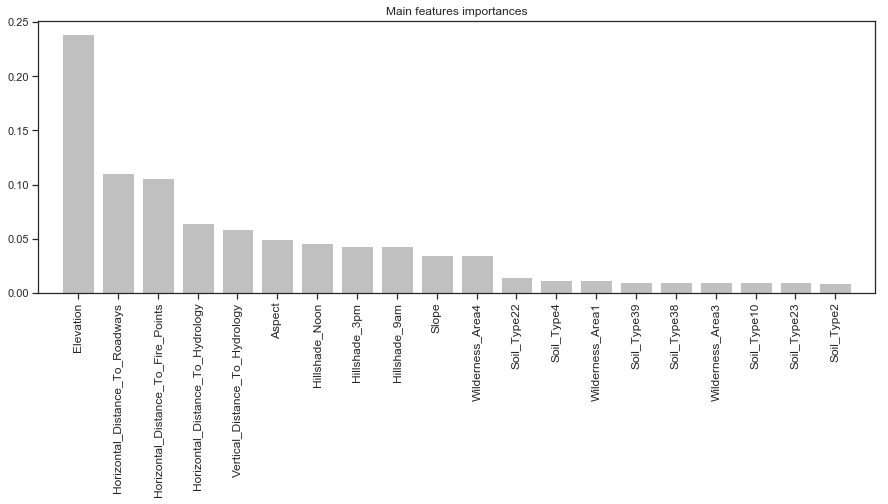

```python
features_importances(rf1, df_train_train, "Cover Type (Initial RF)")
```

**Comment**

- High contribution of Elevation, with a lift 2 times above the 2nd and 3rd variables. This is the main feature, explaining nearby a quarter of the model
- Following : distances (to rodways, to fire points, to hydrology) represent all together more than a third of the ecplained information
- Between 2% and 5% : aspect, hillshades, slope and one type of wilderness area ("Cache la Poudre Wilderness Area")
- Below 2% : all one hot variables concerning soil types and wilderness areas
- Tuning the model with Grid Search : number of trees, max_depth, class_weight

A lot of values have been tested... Here is the final grid

```python
parameters = {'n_estimators': [100, 300, 500],
              'max_depth': [30, 35, 40]}
              #'class_weight': (None,'balanced', 'balanced_subsample')}
rf2 = ensemble.RandomForestClassifier(bootstrap=True,
                             n_jobs=4,
                             class_weight='balanced_subsample')
clf = GridSearchCV(rf2, parameters, cv=3,n_jobs=4)
clf.fit(df_train_train.iloc[:,:-1].values, df_train_train.iloc[:,-1:].values.ravel())
```

```
GridSearchCV(cv=3, error_score='raise',
       estimator=RandomForestClassifier(bootstrap=True, class_weight='balanced_subsample',
            criterion='gini', max_depth=None, max_features='auto',
            max_leaf_nodes=None, min_impurity_decrease=0.0,
            min_impurity_split=None, min_samples_leaf=1,
            min_samples_split=2, min_weight_fraction_leaf=0.0,
            n_estimators=10, n_jobs=4, oob_score=False, random_state=None,
            verbose=0, warm_start=False),
       fit_params=None, iid=True, n_jobs=4,
       param_grid={'n_estimators': [100, 300, 500], 'max_depth': [30, 35, 40]},
       pre_dispatch='2*n_jobs', refit=True, return_train_score='warn',
       scoring=None, verbose=0)
```

**Comment** : The gain is really minim after tuning the hyperparameters

```python
print("Balanced Train score: %.4f" % (clf.score(df_train_train.iloc[:,:-1].values,
                                                         df_train_train.iloc[:,-1:].values.ravel())))
print("Balanced Test score: %.4f" % (clf.score(df_train_test.iloc[:,:-1].values,
                                                         df_train_test.iloc[:,-1:].values.ravel())))
y_pred2 = clf.predict(df_train_test.iloc[:,:-1].values)
```

```
Balanced Train score: 1.0000
Balanced Test score: 0.9392
```

```python
# Confusion matrix
conf_matrix = confusion_matrix(df_train_test.iloc[:,-1:], y_pred2)
np.set_printoptions(precision=2)
conf_matrix
```

```
array([[17754,  1410,     1,     0,     3,     3,    61],
       [  733, 24937,    69,     2,    32,    38,    12],
       [    0,    81,  3036,    15,     1,    70,     0],
       [    0,     0,    37,   198,     0,     5,     0],
       [    9,   206,    13,     0,   631,     2,     0],
       [    1,    86,   151,     5,     2,  1324,     0],
       [  150,    14,     0,     0,     0,     0,  1780]])
```

```python
# Best model properties
clf.best_estimator_
```

```
RandomForestClassifier(bootstrap=True, class_weight='balanced_subsample',
            criterion='gini', max_depth=40, max_features='auto',
            max_leaf_nodes=None, min_impurity_decrease=0.0,
            min_impurity_split=None, min_samples_leaf=1,
            min_samples_split=2, min_weight_fraction_leaf=0.0,
            n_estimators=300, n_jobs=4, oob_score=False, random_state=None,
            verbose=0, warm_start=False)
```

```python
clf.best_params_
```

```
{'max_depth': 40, 'n_estimators': 300}
```

Feature engineering  
Since I had tested under Databricks several multiclass algorithms, I then wanted to try to improve the information provided by the main features, back into the same model at this stage (random forest) for comparison.

- Computing features

Since distances and elevation contributed to almost 2 thirds of the model, I first tried to build features derived from these main distances features, calculating difference and sums betwen the features.

I first wanted to test the impact of integrating these simple features transformations, wich has revealed to be significative. I kept these variables but should have done some further invistigations to understanding non linear relations lying betwen dome variables. I am shure a complementary improvements are possible. I did not take the requiered time for doing this.

```python
df_train_train_mod = df_train_train
df_train_test_mod = df_train_test
```

```python
def tranformations(df):
    # Combining features with simple transformations.
    df["dist_combo_1"] = df['Horizontal_Distance_To_Hydrology'] + df['Horizontal_Distance_To_Fire_Points']
    df["dist_combo_2"] = abs(df['Horizontal_Distance_To_Hydrology'] - df['Horizontal_Distance_To_Fire_Points'])
    df["dist_combo_3"] = abs(df['Horizontal_Distance_To_Hydrology'] + df['Horizontal_Distance_To_Roadways'])
    df["dist_combo_4"] = abs(df['Horizontal_Distance_To_Hydrology'] - df['Horizontal_Distance_To_Roadways'])
    df["dist_combo_5"] = abs(df['Horizontal_Distance_To_Fire_Points'] + df['Horizontal_Distance_To_Roadways'])
    df["dist_combo_6"] = abs(df['Horizontal_Distance_To_Fire_Points'] - df['Horizontal_Distance_To_Roadways'])
    df["dist_combo_7"] = abs(df['Elevation'] - df['Vertical_Distance_To_Hydrology'])
    df["Mean_Distances1"] = (df['Horizontal_Distance_To_Fire_Points'] + df['Horizontal_Distance_To_Hydrology'] \
          + df['Horizontal_Distance_To_Roadways'])/3
    df["Mean_Distances2"] = (df['Horizontal_Distance_To_Fire_Points'] + df['Horizontal_Distance_To_Hydrology'])/2
    # Put back cover_type as the last variable
    cols = list(df.columns.values)
    cols.pop(cols.index('Cover_Type'))
    df = df[cols+['Cover_Type']]
    return df
```

```python
df_train_train_mod = tranformations(df_train_train_mod)
df_train_test_mod = tranformations(df_train_test_mod)
```

```python
# checking the dataset structure after transformations
df_train_train_mod.dtypes
```

```
Elevation                               int64
Aspect                                  int64
Slope                                   int64
Horizontal_Distance_To_Hydrology        int64
Vertical_Distance_To_Hydrology          int64
Horizontal_Distance_To_Roadways         int64
Hillshade_9am                           int64
Hillshade_Noon                          int64
Hillshade_3pm                           int64
Horizontal_Distance_To_Fire_Points      int64
Wilderness_Area1                        int64
Wilderness_Area2                        int64
Wilderness_Area3                        int64
Wilderness_Area4                        int64
Soil_Type1                              int64
Soil_Type2                              int64
Soil_Type3                              int64
Soil_Type4                              int64
Soil_Type5                              int64
Soil_Type6                              int64
Soil_Type7                              int64
Soil_Type8                              int64
Soil_Type9                              int64
Soil_Type10                             int64
Soil_Type11                             int64
Soil_Type12                             int64
Soil_Type13                             int64
Soil_Type14                             int64
Soil_Type15                             int64
Soil_Type16                             int64
                                       ...
Soil_Type21                             int64
Soil_Type22                             int64
Soil_Type23                             int64
Soil_Type24                             int64
Soil_Type25                             int64
Soil_Type26                             int64
Soil_Type27                             int64
Soil_Type28                             int64
Soil_Type29                             int64
Soil_Type30                             int64
Soil_Type31                             int64
Soil_Type32                             int64
Soil_Type33                             int64
Soil_Type34                             int64
Soil_Type35                             int64
Soil_Type36                             int64
Soil_Type37                             int64
Soil_Type38                             int64
Soil_Type39                             int64
Soil_Type40                             int64
dist_combo_1                            int64
dist_combo_2                            int64
dist_combo_3                            int64
dist_combo_4                            int64
dist_combo_5                            int64
dist_combo_6                            int64
dist_combo_7                            int64
Mean_Distances1                       float64
Mean_Distances2                       float64
Cover_Type                              int64
Length: 64, dtype: object
```

Model after feature engineering  
The idea was again to stick with ransom forest, to compare the results with the previous model (raw variables). The number of trees and max depth differ ; these have been manually adapted after several attempts.

```python
rf3=ensemble.RandomForestClassifier(n_estimators=100,
                           class_weight=None,
                           max_depth=40,
                           bootstrap=True,
                           n_jobs=-1,
                          )
rf3.fit(df_train_train_mod.iloc[:,:-1].values, df_train_train_mod.iloc[:,-1:].values.ravel())
```

```
RandomForestClassifier(bootstrap=True, class_weight=None, criterion='gini',
            max_depth=40, max_features='auto', max_leaf_nodes=None,
            min_impurity_decrease=0.0, min_impurity_split=None,
            min_samples_leaf=1, min_samples_split=2,
            min_weight_fraction_leaf=0.0, n_estimators=100, n_jobs=-1,
            oob_score=False, random_state=None, verbose=0,
            warm_start=False)
```

```python
print("New Train score, after feature engineering: %.4f" % (rf3.score(df_train_train_mod.iloc[:,:-1].values,
                                                         df_train_train_mod.iloc[:,-1:].values.ravel())))
print("New Test score, after feature engineering: %.4f" % (rf3.score(df_train_test_mod.iloc[:,:-1].values,
                                                         df_train_test_mod.iloc[:,-1:].values.ravel())))
y_pred3 = rf3.predict(df_train_test_mod.iloc[:,:-1].values)
```

```
New Train score, after feature engineering: 1.0000
New Test score, after feature engineering: 0.9525
```

```python
# Confusion matrix on test set
cnf_matrix = confusion_matrix(df_train_test_mod.iloc[:,-1:], y_pred3)
np.set_printoptions(precision=2)
cnf_matrix
```

```
array([[18219,   949,     0,     0,     7,     1,    56],
       [  681, 25013,    54,     1,    36,    26,    12],
       [    0,    58,  3064,    12,     6,    63,     0],
       [    0,     0,    28,   202,     0,    10,     0],
       [    5,   176,    11,     0,   666,     3,     0],
       [    1,    71,   124,     6,     2,  1365,     0],
       [  103,    10,     0,     0,     0,     0,  1831]])
```

```
Cover Type (RF after feature engeneering) Main important features

1. Elevation (0.136731)
2. dist_combo_7 (0.135383)
3. dist_combo_5 (0.048376)
4. Mean_Distances1 (0.044777)
5. dist_combo_4 (0.040078)
6. dist_combo_3 (0.039920)
7. Horizontal_Distance_To_Roadways (0.039533)
8. dist_combo_6 (0.036435)
9. dist_combo_2 (0.036335)
10. Horizontal_Distance_To_Fire_Points (0.035010)
11. dist_combo_1 (0.034553)
12. Mean_Distances2 (0.033829)
13. Horizontal_Distance_To_Hydrology (0.030614)
14. Vertical_Distance_To_Hydrology (0.029003)
15. Aspect (0.027557)
16. Hillshade_Noon (0.027196)
17. Hillshade_9am (0.025246)
18. Hillshade_3pm (0.023985)
19. Wilderness_Area4 (0.022306)
20. Slope (0.018530)

Mean Feature Importance 0.0158
```

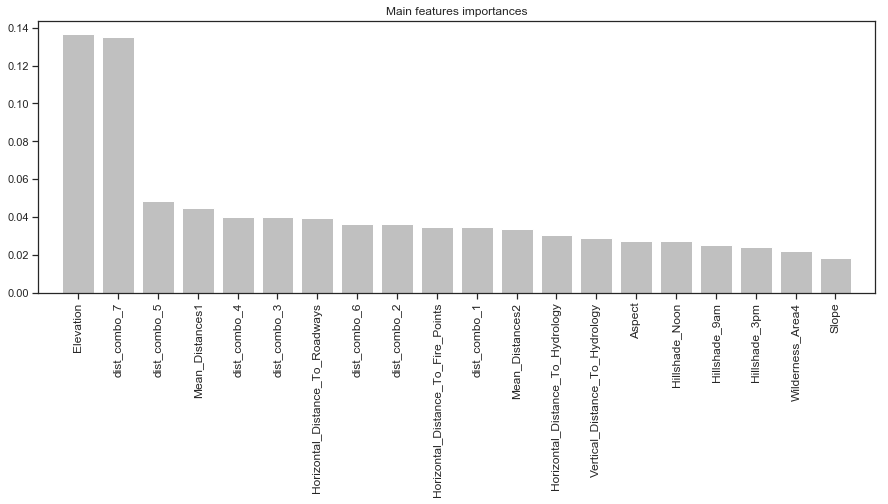

```python
features_importances(rf3, df_train_train_mod, "Cover Type (RF after feature engeneering)")
```

**Comments** An overeall significant improvement after basic features transformations : accuracy of 0,9525 (with transf.) vs 0.9392 before Concerning the features :

- Elevation still holds the first rank but its contribution is reduced in favour of a composed variable (dist_combo_7), combining again elevation and vertical distance to hydrology.
- Overall computed and initial distances variables still represent about 70% of the model explanatory power.
- The overall remaining features is globally unchanged

Optimizing One hot encoders  
My idea was initially to reduce the number of variables used in one hot encoders, trying to capture the relevant information they could endebb. I choose SVC to build a subscore, with the aim to use the probability of belonging to each class (7 variables) as new input variables, in replacement of all the one encoders corresponding to soil types and wilderness area. Note : considering the computation cost (complexity more than quadratic), I ran the learning algorithm over a more concise sample to ensure convergeance. The model has been trained tuning gamma, C, and the kernel type (finally sigmoïd matched best)

```python
df_sample2 = df_train_train_mod.sample(n=10000, frac=None, replace=False, weights=None, axis=None)
```

- Train the model

```python
# SVC over Soil Type and wilderness
```

```python
transf = svm.SVC(kernel = 'sigmoid',
                 decision_function_shape='ovr',
                 class_weight=None,
                 gamma='auto',
                 probability=True)
transf.fit(df_sample2.iloc[:,10:54].values, df_sample2.iloc[:,-1:].values.ravel())
```

[output not shown]

```python
# Code used for tuning SVC.
"""from sklearn.model_selection import StratifiedShuffleSplit
C_range = np.logspace(-2, 10, 13)
gamma_range = np.logspace(-9, 3, 13)
param_grid = dict(gamma=gamma_range, C=C_range)
cv = StratifiedShuffleSplit(n_splits=5, test_size=0.2)
grid = GridSearchCV(svm.SVC(kernel = 'sigmoid',
                 decision_function_shape='ovo',
                 class_weight=None), param_grid=param_grid, cv=cv,n_jobs=-1)
grid.fit(df_sample2.iloc[:,10:54].values, df_sample2.iloc[:,-1:].values.ravel())

print("The best parameters are %s with a score of %0.2f"
      % (grid.best_params_, grid.best_score_))"""
```

[output not shown]

- Model performance

**Comment** : a weak performance but rather stable

```python
# Score on sample train set
transf.score(df_sample2.iloc[:,10:54].values, df_sample2.iloc[:,-1:].values.ravel())
```

[output not shown]

```python
# Score on test set
transf.score(df_train_test_mod.iloc[:,10:54].values, df_train_test_mod.iloc[:,-1:].values.ravel())
```

```
0.6394121652292328
```

- Applying the model to both train and test datasets

```python
res_train = transf.predict_proba(df_train_train_mod.iloc[:,10:54].values)
```

```python
res_test = transf.predict_proba(df_train_test_mod.iloc[:,10:54].values)
```

```python
res_test.shape
```

```
(52872, 7)
```

- Constitute the final datasets

```python
# drop the one encoders
start = 10
cols = [i + start for i in range(44)]
df_train_train_mod2 = df_train_train_mod.drop(df_train_train_mod.columns[cols],axis=1,inplace=False)
df_train_test_mod2 = df_train_test_mod.drop(df_train_test_mod.columns[cols],axis=1,inplace=False)
```

```python
# Check the dataset structure after dropping variables
df_train_train_mod2.dtypes
```

```
Elevation                               int64
Aspect                                  int64
Slope                                   int64
Horizontal_Distance_To_Hydrology        int64
Vertical_Distance_To_Hydrology          int64
Horizontal_Distance_To_Roadways         int64
Hillshade_9am                           int64
Hillshade_Noon                          int64
Hillshade_3pm                           int64
Horizontal_Distance_To_Fire_Points      int64
dist_combo_1                            int64
dist_combo_2                            int64
dist_combo_3                            int64
dist_combo_4                            int64
dist_combo_5                            int64
dist_combo_6                            int64
dist_combo_7                            int64
Mean_Distances1                       float64
Mean_Distances2                       float64
Cover_Type                              int64
dtype: object
```

```python
def add_df_from_svm(df,res):
    for i in range(7):
        df['prob_'+str(i+1)]=res[:,i:(i+1)]
    # move cover_type to last column
    cols = list(df.columns.values)
    cols.pop(cols.index('Cover_Type'))
    df = df[cols+['Cover_Type']]
    return df
```

```python
# add the 7 probabilities
df_train_train_mod3 = add_df_from_svm(df_train_train_mod2,res_train)
df_train_test_mod3 = add_df_from_svm(df_train_test_mod2,res_test)
```

```python
# Check dataset structure
df_train_train_mod3.dtypes
```

```
Elevation                               int64
Aspect                                  int64
Slope                                   int64
Horizontal_Distance_To_Hydrology        int64
Vertical_Distance_To_Hydrology          int64
Horizontal_Distance_To_Roadways         int64
Hillshade_9am                           int64
Hillshade_Noon                          int64
Hillshade_3pm                           int64
Horizontal_Distance_To_Fire_Points      int64
dist_combo_1                            int64
dist_combo_2                            int64
dist_combo_3                            int64
dist_combo_4                            int64
dist_combo_5                            int64
dist_combo_6                            int64
dist_combo_7                            int64
Mean_Distances1                       float64
Mean_Distances2                       float64
prob_1                                float64
prob_2                                float64
prob_3                                float64
prob_4                                float64
prob_5                                float64
prob_6                                float64
prob_7                                float64
Cover_Type                              int64
dtype: object
```

```python
df_train_train_mod3.shape
```

```
(475848, 27)
```

Models after one hot submodel  
Let's see if there is any improvement to the random forest model. I saw a little improuvment I then tried hard to upgrade by fine tuning all the hyperparameters (nb of trees, impurity, class_weight (unbalanced classes), min_samples_leaf and min_saples_split, max_feature) ; below is the final implementation of the model :

- Random Forest

```python
rf5=ensemble.RandomForestClassifier(n_estimators=300,
                           class_weight=None,
                           criterion = 'entropy',
                           max_depth=35,
                           bootstrap=True,
                           #min_samples_leaf=5,
                           n_jobs=-1,
                           #min_samples_split=5
                           #max_features=0.8
                          )
rf5.fit(df_train_train_mod3.iloc[:,:-1].values, df_train_train_mod3.iloc[:,-1:].values.ravel())
```

```
RandomForestClassifier(bootstrap=True, class_weight=None, criterion='entropy',
            max_depth=35, max_features='auto', max_leaf_nodes=None,
            min_impurity_decrease=0.0, min_impurity_split=None,
            min_samples_leaf=1, min_samples_split=2,
            min_weight_fraction_leaf=0.0, n_estimators=300, n_jobs=-1,
            oob_score=False, random_state=None, verbose=0,
            warm_start=False)
```

```python
print("New Train score, with one hot submodel: %.4f" % (rf5.score(df_train_train_mod3.iloc[:,:-1].values,
                                                         df_train_train_mod3.iloc[:,-1:].values.ravel())))
print("New Test score, with one hot submodel: %.4f" % (rf5.score(df_train_test_mod3.iloc[:,:-1].values,
                                                         df_train_test_mod3.iloc[:,-1:].values.ravel())))
y_pred5 = rf5.predict(df_train_test_mod3.iloc[:,:-1].values)
```

```
New Train score, with one hot submodel: 1.0000
New Test score, with one hot submodel: 0.9554
```

Kaggle Submission #1 :  
A subtle improvement of accuracy on the test model. This model has been submitted to Kaggle.

```python
# Compute confusion matrix
cnf_matrix = confusion_matrix(df_train_test_mod3.iloc[:,-1:], y_pred5)
np.set_printoptions(precision=2)
cnf_matrix
```

```
array([[18276,   879,     1,     0,    13,     3,    60],
       [  648, 25031,    53,     0,    43,    39,     9],
       [    0,    49,  3069,    15,     7,    63,     0],
       [    0,     0,    23,   206,     0,    11,     0],
       [    7,   138,    12,     0,   701,     2,     1],
       [    0,    65,   106,     6,     3,  1389,     0],
       [   93,    10,     0,     0,     0,     0,  1841]])
```

```
Cover Type (RF  with one hot submodel) Main important features

1. dist_combo_7 (0.128629)
2. Elevation (0.113769)
3. prob_6 (0.057279)
4. prob_3 (0.056462)
5. prob_1 (0.047826)
6. prob_2 (0.046209)
7. prob_7 (0.038374)
8. dist_combo_5 (0.037713)
9. Mean_Distances1 (0.036118)
10. dist_combo_4 (0.034042)
11. dist_combo_3 (0.032716)
12. Horizontal_Distance_To_Roadways (0.032317)
13. prob_4 (0.031852)
14. dist_combo_6 (0.031205)
15. dist_combo_2 (0.029731)
16. Horizontal_Distance_To_Fire_Points (0.028949)
17. dist_combo_1 (0.027548)
18. Mean_Distances2 (0.027444)
19. Horizontal_Distance_To_Hydrology (0.024718)
20. Vertical_Distance_To_Hydrology (0.023448)

Mean Feature Importance 0.0384
```

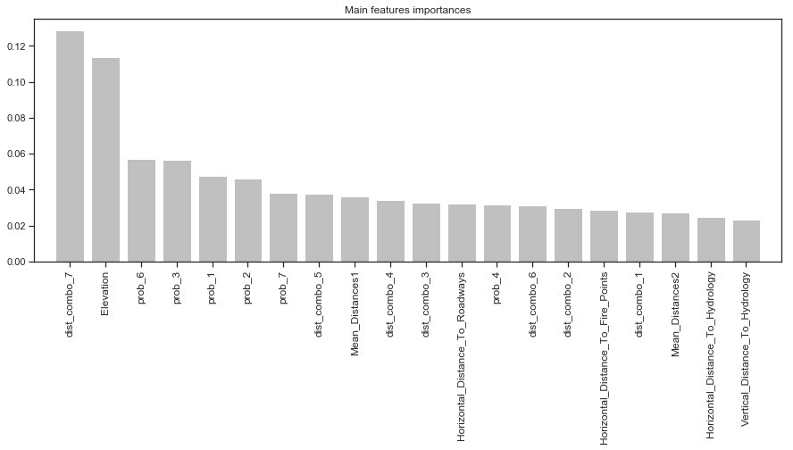

```python
features_importances(rf5, df_train_train_mod3, "Cover Type (RF  with one hot submodel)")
```

**Comments**

A tiny improvement after integrating the "one hot" probabilities.

We can now see these variables in the main model features, nevertheless still behind elevation and its derivate

Features Selection - Trying to build a more concise model with only the important features  
I tried to build a model with only the most significant features of the previous model. I hopes to gain stability and robustness. The results were desappointing, leading to a loss of precision.

- Let's build a model with only the important features

```python
f_i = rf5.feature_importances_
ix = np.argsort(f_i)[::-1]
l = []
for f in range(df_train_train_mod3.shape[1]-1) :
    if (f_i[ix[f]] > (0.025)):
        l.append(df_train_train_mod3.columns[ix[f]])
l.append('Cover_Type')
print(l)
df_train_train_mod4 = df_train_train_mod3[l]
df_train_test_mod4 = df_train_test_mod3[l]
```

[output not shown]

```python
df_train_test_mod4.shape
```

```
(52872, 19)
```

```python
rf6=ensemble.RandomForestClassifier(n_estimators=300,
                           class_weight=None,
                           criterion = 'entropy',
                           max_depth=40,
                           bootstrap=True,
                           min_samples_leaf=10,
                           n_jobs=-1,
                           min_samples_split=10
                          )
rf6.fit(df_train_train_mod4.iloc[:,:-1].values, df_train_train_mod4.iloc[:,-1:].values.ravel())
```

```
RandomForestClassifier(bootstrap=True, class_weight=None, criterion='entropy',
            max_depth=40, max_features='auto', max_leaf_nodes=None,
            min_impurity_decrease=0.0, min_impurity_split=None,
            min_samples_leaf=10, min_samples_split=10,
            min_weight_fraction_leaf=0.0, n_estimators=300, n_jobs=-1,
            oob_score=False, random_state=None, verbose=0,
            warm_start=False)
```

```python
print("New Train score, with one hot submodel and features selection: %.4f" % (rf6.score(df_train_train_mod4.iloc[:,:-1].values,
                                                         df_train_train_mod4.iloc[:,-1:].values.ravel())))
print("New Test score, with one hot submodel and features selection: %.4f" % (rf6.score(df_train_test_mod4.iloc[:,:-1].values,
                                                         df_train_test_mod4.iloc[:,-1:].values.ravel())))
y_pred6 = rf6.predict(df_train_test_mod4.iloc[:,:-1].values)
```

```
New Train score, with one hot submodel and features selection: 0.9580
New Test score, with one hot submodel and features selection: 0.9320
```

```python
# Compute confusion matrix
cnf_matrix = confusion_matrix(df_train_test_mod3.iloc[:,-1:], y_pred5)
np.set_printoptions(precision=2)
cnf_matrix
```

[output not shown]

Other methods attempts  
Complementary attempts, using other methods : extratrees and one vs rest model based on random forest. This last algorithm gave a relative good score (almost equal to the random forest itself though), and has been submitted too to Kaggle.

- ExtraTreesClassifier (just a few tunings tried)

```python
#min_samples_split=4,
et1=ensemble.ExtraTreesClassifier(n_estimators=500,
                           class_weight=None,
                           criterion = 'entropy',
                           max_depth=40,
                           bootstrap=True,
                           min_samples_leaf=5,
                           n_jobs=-1,
                           verbose = 0
                          )
```

```python
et1.fit(df_train_train_mod3.iloc[:,:-1].values, df_train_train_mod3.iloc[:,-1:].values.ravel())
```

```python
print("New Extra Trees Train score, with one hot submodel : %.4f" % (et1.score(df_train_train_mod3.iloc[:,:-1].values,
                                                         df_train_train_mod3.iloc[:,-1:].values.ravel())))
print("New Extra Trees Test score, with one hot submodel: %.4f" % (et1.score(df_train_test_mod3.iloc[:,:-1].values,
                                                         df_train_test_mod3.iloc[:,-1:].values.ravel())))
y_pred6 = et1.predict(df_train_test_mod3.iloc[:,:-1].values)
```

[output not shown]

```python
# Compute confusion matrix
cnf_matrix = confusion_matrix(df_train_test_mod3.iloc[:,-1:], y_pred6)
np.set_printoptions(precision=2)
cnf_matrix
```

[output not shown]

- One vs rest

```python
rf7=ensemble.RandomForestClassifier(n_estimators=100,
                           class_weight='balanced',
                           criterion = 'entropy',
                           max_depth=35,
                           bootstrap=True,
                           n_jobs=-1,
                           max_features=0.05
                          )
```

```python
from sklearn.multiclass import OneVsRestClassifier
ovr=OneVsRestClassifier(rf7, n_jobs=-1)
```

```python
ovr.fit(df_train_train_mod3.iloc[:,:-1].values, df_train_train_mod3.iloc[:,-1:].values.ravel())
```

```
OneVsRestClassifier(estimator=RandomForestClassifier(bootstrap=True, class_weight='balanced',
            criterion='entropy', max_depth=35, max_features=0.05,
            max_leaf_nodes=None, min_impurity_decrease=0.0,
            min_impurity_split=None, min_samples_leaf=1,
            min_samples_split=2, min_weight_fraction_leaf=0.0,
            n_estimators=100, n_jobs=-1, oob_score=False,
            random_state=None, verbose=0, warm_start=False),
          n_jobs=-1)
```

```python
print("New One vs Rest Train score, with one hot submodel : %.4f" % (ovr.score(df_train_train_mod3.iloc[:,:-1].values,
                                                         df_train_train_mod3.iloc[:,-1:].values.ravel())))
print("New One vs Rest Test score, with one hot submodel: %.4f" % (ovr.score(df_train_test_mod3.iloc[:,:-1].values,
                                                         df_train_test_mod3.iloc[:,-1:].values.ravel())))
#df_train_test_mod3
```

```
New One vs Rest Train score, with one hot submodel: 1.0000
New One vs Rest Test score, with one hot submodel: 0.9556
```

Kaggle Submission #2 :  
A tiny improvement of accuracy on the test model. This model has been submitted to Kaggle as well.

```python
# Compute confusion matrix
y_pred6 = grd.predict(df_train_test_mod3.iloc[:,:-1].values)
cnf_matrix = confusion_matrix(df_train_test_mod3.iloc[:,-1:], y_pred6)
np.set_printoptions(precision=2)
cnf_matrix
```

[output not shown]

Attempt to combine methods  
No probant results...

```python
eclf = ensemble.VotingClassifier(estimators=[ ('rf', rf5), ('et', et1)], voting='soft',
        n_jobs=-1)
```

```python
eclf.fit(df_train_train_mod3.iloc[:,:-1].values, df_train_train_mod3.iloc[:,-1:].values.ravel())
```

[output not shown]

```python
print("New Models combination : %.4f" % (eclf.score(df_train_train_mod3.iloc[:,:-1].values,
                                                         df_train_train_mod3.iloc[:,-1:].values.ravel())))
print("New Models combination : %.4f" % (eclf.score(df_train_test_mod3.iloc[:,:-1].values,
                                                         df_train_test_mod3.iloc[:,-1:].values.ravel())))
y_pred7 = eclf.predict(df_train_test_mod3.iloc[:,:-1].values)
```

[output not shown]

[output not shown]

```python
# Compute confusion matrix
cnf_matrix = confusion_matrix(df_train_test_mod3.iloc[:,-1:], y_pred7)
np.set_printoptions(precision=2)
cnf_matrix
```

[output not shown]

Run Predictions and Submit to Kaggle

```python
# Prépare the dataset for scoring applying transformations
df_score['Cover_Type'] = 0
df_score = tranformations(df_score)
# calculating the subscore for one hot variables
res_score = transf.predict_proba(df_score.iloc[:,10:54].values)
# Merging and cleaning the dataset
start = 10
cols = [i + start for i in range(44)]
df_score = df_score.drop(df_score.columns[cols],axis=1,inplace=False)
df_score = add_df_from_svm(df_score,res_score)
df_score2 = df_score.drop(df_score.columns[-1],axis=1,inplace=False)
```

```python
# applying the model on a df copy
temp=df_score2.copy()
temp['Cover_Type']=ovr.predict(temp.values)
# Selecting the columns and exporting to file
temp=temp['Cover_Type']
temp.to_csv('Test_Kaggle_submit2.csv', header=True)
```